# Rmarkdown ve R’ı birleştirmek

Şubat 19, 2020

## Bir makaleyi nasıl yazarız?

## Örnek

[figure not shown]

## Tablolar var

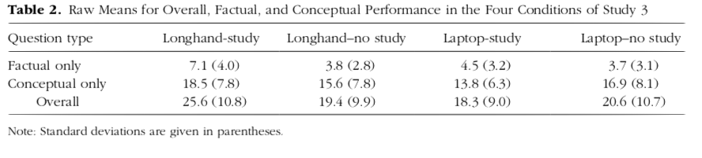

Sahip olduğunuz veriye bağlı

Veriniz değişirse, tablolar da değişir…

## Figürler de dahil

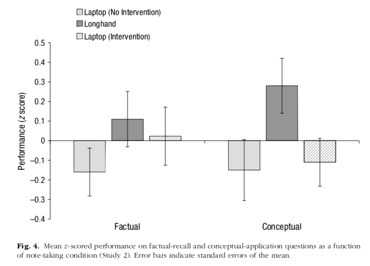

## Bir diyagram

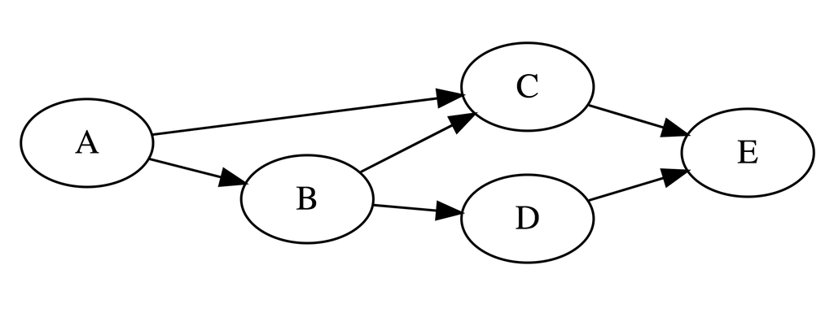

## Bir harita

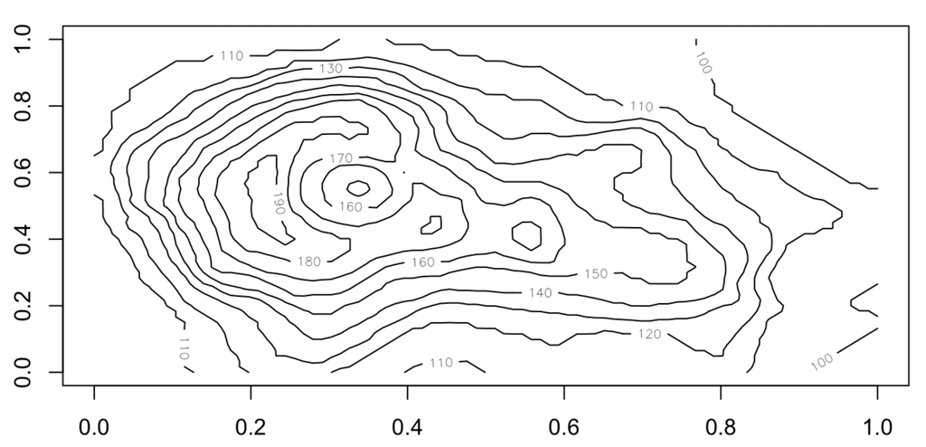

## Ya da renkli bir harita

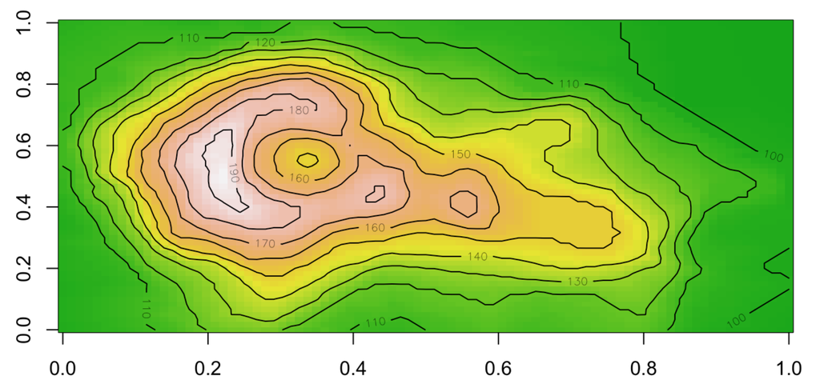

## Veya perspektif

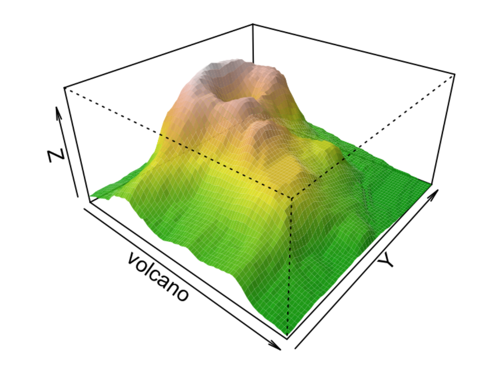

## Belgeniz, verinize bağlı

Bilimsel sonuçlarınız, verilerinize bağlı

Verileriniz değişirse, yayın da değişir

Belgenizin içinde R kodu kullanmanız gerek

## R ve Rmarkdown birleştirmek

## Markdown

Kelime işlemcilere alternatif bir yol,

Metin dosyaları, her bilgisayarda aynı şekilde oluşturulabilir ve her türlü platformda okunabilir.

**Yapılandırılmış dökümanlar** genelde *Markdown* belge hazırlama biçimini kullanır.

## RMarkdown

*Rstudio* içerisinde, R kodunu ve Markdown belge hazırlama biçimini birleştirebiliriz!

Sadece `rmarkdown` paketini indirmeniz gerek

## Üstveri

Belgenin en üstünde başlar ve üç tane tire ile belirtilir `---`

Bu değişkenler bütün dökümanı etkiler!

- `title:`
- `author:`
- `date:`
- `number:` (for the student number)
- `output`

## Üstveri

```
---
title: "Vize Sınavı"
author: "Öğrencinin İsmi"
number: 0405678912
date: "Tarih"
output: html_document
---
```

Bu bloğun üç tane tire `---` ile belirtildiğine dikkat edin

**Mutlaka** `:` işaretinden sonra bir boşluk belirtin

**Mutlaka** satır başından başlayın

**Mutlaka** öğrenci numaranızı yazın!

## Paragraflar

Herhangi bir işaret kullanılmayan bütün satırlar paragraf olarak tanımlanır.

```
The first paragraph.

Another paragraph
```

> The first paragraph.

> Another paragraph

## Alıntılar

Each line is preceded by a `>` character and a space.

```
> This is something important, like your answer to the exam
>
> Another paragraph
```

This is something important, like your answer to the exam

Another paragraph

## Bilgisayar kodu

Programlar genellikle sabit genişlikli bir font ile yazılır

````
```
this <- is.computer(code)
```
````

```
this <- is.computer(code)
```

Ancak bu kodlar çalıştırılmaz!

## R kodu

Eğer gerçekten bu kodu çalıştırmak istersek `{r}` yazmamız gerek

````
```{r}
seq(from=2, to=10)
rep("A", 3)
```
````

```
[1]  2  3  4  5  6  7  8  9 10
```

```
[1] "A" "A" "A"
```

## Kod Öbekleri (Chunk)

Öbekler, Rmd dökümanı içerisinde bulunan R kodlarıdır

Her öbek `` ```{r} `` ile başlar ve `` ``` `` ile biter!

(each one in a separate line, without spaces)

## Öbeklerler bir bir çalıştırılır

[figure not shown]

## Öbeklerin isimler var

Bu sayede dökümanınızda kolaylıkla hata ayıklayabilirsiniz

````
```{r print_sequences}
seq(from=2, to=10)
rep("A", 3)
```
````

İsimler veya `.` işaretlerine sahip olamaz!

## Öbeklerin bazı opsiyonları var

Rstüdyo içerisinde öbekler gri ile formatlanır

Sağ üstteki ikonlar

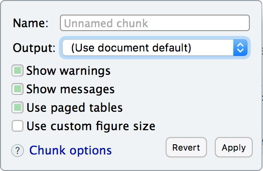

İlk ikon öbek opsiyonlarını açar

## Bazı yararlı opsiyonlar

You can also write them directly

## Varsayılan opsiyonlar

`knitr::opts_chunk$set()` bütün öbek opsiyonlarını değiştirir

Farkettiyseniz bunu en başta tanımladık!

````
```{r setup, include=FALSE, echo = T, eval=F}
knitr::opts_chunk$set(echo = TRUE)
```
````

## Örnekler

Last class I wrote:

````
```{r, echo=T, eval=F}
seq(from=4, by=2, length=4)
```
````

sonucunda:

```r
seq(from=4, by=2, length=4)
```

```
[1]  4  6  8 10
```

## Değişkenler, kod blokları arasında tanımlanabilr

````
```{r, echo=T, eval=F}
agirlik <- c(60, 72, 57, 90, 95, 72)
```
````

```r
agirlik
```

sonucunda:

```r
agirlik <- c(60, 72, 57, 90, 95, 72)
```

```r
agirlik
```

```
[1] 60 72 57 90 95 72
```

## Öbekler can have several outputs

````
```{r, echo=T, eval=F}
agirlik[3]
agirlik[-3]
```
````

sonucunda:

```r
agirlik[3]
```

```
[1] 57
```

```r
agirlik[-3]
```

```
[1] 60 72 90 95 72
```

## Daha fazla bilgi

Mesela bu güzel bir kaynak:

[Rmarkdown ile çalışmak](https://ourcodingclub.github.io/2016/11/24/rmarkdown-1.html)